# RD modelling - simulations

Doranne Thomassen

3/22/2021

# Single trial

## Binary treatment variable only

### Sample size 50 per arm

```r
set.seed(196)
n_arm <- 50
treat <- c(rep(0,n_arm), rep(1,n_arm))
cat("", file = "modelstats.html", append = FALSE)

beta_xlim = c(-0.3,0.7)
beta_ylim = c(0,40)
#beta fixed, increase alpha

#alpha = 0.5
true.beta <- 0.3
true.p <- 0.5+true.beta*treat

cure <- rbinom(n=length(treat), size=1, prob = true.p)
trial.dat <- data.frame(cure, treat)
print(table(trial.dat$cure, trial.dat$treat))
```

```
##
##      0  1
##   0 20  9
##   1 30 41
```

```r
plots <- run.sim(true.beta=true.beta,
        trial.dat = trial.dat,
        filename="1x_bin_p=0.5+0.3x",
        title="x_{i1} binary, p_{i}=0.5+0.3x_{i1}",
        true.p = true.p,
        beta_xlim = beta_xlim,
        beta_ylim = beta_ylim)

beta.plot <- plots$beta.frame
xicpt.plot <- plots$xicpt
plots$kable_modstats
```

1. Proposed model
3. Logistic model + transform
2. Model by Warn et al.

MLE binomial GLM id-link

MLE binomial GLM logit-link

OLS estimate

Brier.mean

0.1939

0.1938

0.1939

0.1938

0.1938

0.1938

Brier.median

0.1938

0.1938

0.1938

0.1938

0.1938

0.1938

RMSE.p.mean

0.0677

0.0739

0.0689

0.0721

0.0721

0.0721

RMSE.p.median

0.0698

0.0755

0.0706

0.0721

0.0721

0.0721

MAE.p.mean

0.0518

0.0609

0.0514

0.0600

0.0600

0.0600

MAE.p.median

0.0552

0.0642

0.0547

0.0600

0.0600

0.0600

L1_loss.mean

0.0873

0.0838

0.0916

0.0800

0.0800

0.0800

L1_loss.median

0.0864

0.0800

0.0906

0.0800

0.0800

0.0800

IC

118.0879

118.4558

118.2934

118.4405

118.4405

NA

Rhat_Conv

1.0005

1.0005

1.0006

-1.0000

-1.0000

-1.0000

RunTimes

1.1380

1.7290

1.0419

0.0042

0.0012

0.0010

ESS

2000.0000

2000.0000

2000.0000

0.0000

0.0000

0.0000

ESSp0

2000.0000

2000.0000

2000.0000

0.0000

0.0000

0.0000

ESSp1

2000.0000

2000.0000

2000.0000

0.0000

0.0000

0.0000

```r
rm(cure, trial.dat, true.beta, true.p)

#alpha = 0.6
true.beta <- 0.3
true.p <- 0.6+true.beta*treat

cure <- rbinom(n=length(treat), size=1, prob = true.p)
trial.dat <- data.frame(cure, treat)
print(table(trial.dat$cure, trial.dat$treat))
```

```
##
##      0  1
##   0 24  7
##   1 26 43
```

```r
plots <- run.sim(true.beta=true.beta,
        trial.dat = trial.dat,
        filename="1x_bin_p=0.6+0.3x",
        title="x_{i1} binary, p_{i}=0.6+0.3x_{i1}",
        true.p = true.p,
        beta_xlim = beta_xlim,
        beta_ylim = beta_ylim)

beta.plot <- rbind(beta.plot, plots$beta.frame)
xicpt.plot <- rbind(xicpt.plot, plots$xicpt)
plots$kable_modstats
```

1. Proposed model
3. Logistic model + transform
2. Model by Warn et al.

MLE binomial GLM id-link

MLE binomial GLM logit-link

OLS estimate

Brier.mean

0.1851

0.1850

0.1851

0.1850

0.1850

0.1850

Brier.median

0.1850

0.1850

0.1851

0.1850

0.1850

0.1850

RMSE.p.mean

0.0681

0.0620

0.0677

0.0632

0.0632

0.0632

RMSE.p.median

0.0661

0.0598

0.0659

0.0632

0.0632

0.0632

MAE.p.mean

0.0671

0.0592

0.0665

0.0600

0.0600

0.0600

MAE.p.median

0.0643

0.0564

0.0645

0.0600

0.0600

0.0600

L1_loss.mean

0.0234

0.0368

0.0247

0.0400

0.0400

0.0400

L1_loss.median

0.0235

0.0377

0.0244

0.0400

0.0400

0.0400

IC

113.7855

113.7357

113.3451

113.7310

113.7310

NA

Rhat_Conv

1.0037

1.0025

1.0007

-1.0000

-1.0000

-1.0000

RunTimes

1.1277

1.9252

1.1646

0.0011

0.0013

0.0006

ESS

470.0000

1500.0000

2000.0000

0.0000

0.0000

0.0000

ESSp0

960.0000

2000.0000

1200.0000

0.0000

0.0000

0.0000

ESSp1

550.0000

2000.0000

2000.0000

0.0000

0.0000

0.0000

```r
rm(cure, trial.dat, true.beta, true.p)

# alpha =0.69
true.beta <- 0.3
true.p <- 0.69+true.beta*treat

cure <- rbinom(n=length(treat), size=1, prob = true.p)
trial.dat <- data.frame(cure, treat)
print(table(trial.dat$cure, trial.dat$treat))
```

```
##
##      0  1
##   0 13  0
##   1 37 50
```

```r
plots <- run.sim(true.beta=true.beta,
        trial.dat = trial.dat,
        filename="1x_bin_p=0.69+0.3x",
        title="x_{i1} binary, p_{i}=0.69+0.3x_{i1}",
        true.p = true.p,
        beta_xlim = beta_xlim,
        beta_ylim = beta_ylim)

beta.plot <- rbind(beta.plot, plots$beta.frame)
xicpt.plot <- rbind(xicpt.plot, plots$xicpt)
plots$kable_modstats
```

1. Proposed model
3. Logistic model + transform
2. Model by Warn et al.

MLE binomial GLM id-link

MLE binomial GLM logit-link

OLS estimate

Brier.mean

0.0965

0.0962

0.0962

0.0962

0.0962

0.0962

Brier.median

0.0964

0.0962

0.0962

0.0962

0.0962

0.0962

RMSE.p.mean

0.0269

0.0379

0.0324

0.0361

0.0361

0.0361

RMSE.p.median

0.0281

0.0408

0.0358

0.0361

0.0361

0.0361

MAE.p.mean

0.0230

0.0288

0.0271

0.0300

0.0300

0.0300

MAE.p.median

0.0218

0.0328

0.0298

0.0300

0.0300

0.0300

L1_loss.mean

0.0459

0.0490

0.2916

0.0400

0.0400

0.0400

L1_loss.median

0.0490

0.0511

0.2872

0.0400

0.0400

0.0400

IC

63.3839

60.7511

59.3700

61.3057

61.3057

NA

Rhat_Conv

1.0054

1.0005

1.0005

-1.0000

-1.0000

-1.0000

RunTimes

1.0348

1.7634

0.9589

0.0014

0.0022

0.0006

ESS

470.0000

2000.0000

2000.0000

0.0000

0.0000

0.0000

ESSp0

260.0000

2000.0000

2000.0000

0.0000

0.0000

0.0000

ESSp1

2000.0000

950.0000

2000.0000

0.0000

0.0000

0.0000

```r
rm(cure, trial.dat, true.beta, true.p)


###
#alpha = 0.8
true.beta <- 0
true.p <- 0.8+true.beta*treat

cure <- rbinom(n=length(treat), size=1, prob = true.p)
trial.dat <- data.frame(cure, treat)
print(table(trial.dat$cure, trial.dat$treat))
```

```
##
##      0  1
##   0 11  9
##   1 39 41
```

```r
plots <- run.sim(true.beta=true.beta,
        trial.dat = trial.dat,
        filename="1x_bin_p=0.8+0x",
        title="x_{i1} binary, p_{i}=0.8+0*x_{i1}",
        true.p = true.p,
        beta_xlim = beta_xlim,
        beta_ylim = beta_ylim)

beta.plot <- rbind(beta.plot, plots$beta.frame)
xicpt.plot <- rbind(xicpt.plot, plots$xicpt)
plots$kable_modstats
```

1. Proposed model
3. Logistic model + transform
2. Model by Warn et al.

MLE binomial GLM id-link

MLE binomial GLM logit-link

OLS estimate

Brier.mean

0.1597

0.1596

0.1597

0.1596

0.1596

0.1596

Brier.median

0.1597

0.1596

0.1597

0.1596

0.1596

0.1596

RMSE.p.mean

0.0222

0.0201

0.0235

0.0200

0.0200

0.0200

RMSE.p.median

0.0208

0.0214

0.0225

0.0200

0.0200

0.0200

MAE.p.mean

0.0188

0.0199

0.0202

0.0200

0.0200

0.0200

MAE.p.median

0.0192

0.0205

0.0203

0.0200

0.0200

0.0200

L1_loss.mean

0.0376

0.0398

0.0403

0.0400

0.0400

0.0400

L1_loss.median

0.0373

0.0395

0.0392

0.0400

0.0400

0.0400

IC

103.6077

104.0166

103.5515

103.8301

103.8301

NA

Rhat_Conv

1.0006

1.0006

1.0011

-1.0000

-1.0000

-1.0000

RunTimes

1.0674

1.6374

1.0437

0.0020

0.0028

0.0009

ESS

2000.0000

2000.0000

2000.0000

0.0000

0.0000

0.0000

ESSp0

1600.0000

2000.0000

2000.0000

0.0000

0.0000

0.0000

ESSp1

2000.0000

2000.0000

2000.0000

0.0000

0.0000

0.0000

```r
rm(cure, trial.dat, true.beta, true.p)

#alpha = 0.9
true.beta <- 0
true.p <- 0.9+true.beta*treat

cure <- rbinom(n=length(treat), size=1, prob = true.p)
trial.dat <- data.frame(cure, treat)
print(table(trial.dat$cure, trial.dat$treat))
```

```
##
##      0  1
##   0  1  7
##   1 49 43
```

```r
plots <- run.sim(true.beta=true.beta,
        trial.dat = trial.dat,
        filename="1x_bin_p=0.9+0x",
        title="x_{i1} binary, p_{i}=0.9+0*x_{i1}",
        true.p = true.p,
        beta_xlim = beta_xlim,
        beta_ylim = beta_ylim)

beta.plot <- rbind(beta.plot, plots$beta.frame)
xicpt.plot <- rbind(xicpt.plot, plots$xicpt)
plots$kable_modstats
```

1. Proposed model
3. Logistic model + transform
2. Model by Warn et al.

MLE binomial GLM id-link

MLE binomial GLM logit-link

OLS estimate

Brier.mean

0.0703

0.0700

0.0702

0.0700

0.0700

0.0700

Brier.median

0.0701

0.0700

0.0701

0.0700

0.0700

0.0700

RMSE.p.mean

0.0573

0.0612

0.0588

0.0632

0.0632

0.0632

RMSE.p.median

0.0580

0.0635

0.0600

0.0632

0.0632

0.0632

MAE.p.mean

0.0572

0.0579

0.0587

0.0600

0.0600

0.0600

MAE.p.median

0.0572

0.0583

0.0592

0.0600

0.0600

0.0600

L1_loss.mean

0.1144

0.1157

0.1173

0.1200

0.1200

0.1200

L1_loss.median

0.1123

0.1123

0.1158

0.1200

0.1200

0.1200

IC

54.4301

54.0293

54.3778

54.3003

54.3003

NA

Rhat_Conv

1.0009

1.0016

1.0006

-1.0000

-1.0000

-1.0000

RunTimes

1.0768

1.6897

0.9738

0.0010

0.0011

0.0006

ESS

2000.0000

2000.0000

2000.0000

0.0000

0.0000

0.0000

ESSp0

740.0000

2000.0000

2000.0000

0.0000

0.0000

0.0000

ESSp1

2000.0000

1700.0000

2000.0000

0.0000

0.0000

0.0000

```r
rm(cure, trial.dat, true.beta, true.p)


# alpha = 0.99
true.beta <- 0
true.p <- 0.99 + true.beta*treat

cure <- rbinom(n=length(treat), size=1, prob = true.p)
trial.dat <- data.frame(cure, treat)
print(table(trial.dat$cure, trial.dat$treat))
```

```
##
##      0  1
##   0  1  0
##   1 49 50
```

```r
plots <- run.sim(true.beta=true.beta,
        trial.dat = trial.dat,
        filename="1x_bin_p=0.99+0x",
        title="x_{i1} binary, p_{i}=0.99+0*x_{i1}",
        true.p = true.p,
        beta_xlim = beta_xlim,
        beta_ylim = beta_ylim)

beta.plot <- rbind(beta.plot, plots$beta.frame)
xicpt.plot <- rbind(xicpt.plot, plots$xicpt)
plots$kable_modstats
```

1. Proposed model
3. Logistic model + transform
2. Model by Warn et al.

MLE binomial GLM id-link

MLE binomial GLM logit-link

OLS estimate

Brier.mean

0.0102

0.0098

0.0100

0.0098

0.0098

0.0098

Brier.median

0.0100

0.0098

0.0099

0.0098

0.0098

0.0098

RMSE.p.mean

0.0208

0.0071

0.0214

0.0100

0.0100

0.0100

RMSE.p.median

0.0159

0.0070

0.0175

0.0100

0.0100

0.0100

MAE.p.mean

0.0188

0.0071

0.0192

0.0100

0.0100

0.0100

MAE.p.median

0.0129

0.0055

0.0163

0.0100

0.0100

0.0100

L1_loss.mean

0.0176

0.0143

0.4785

0.0200

0.0200

0.0200

L1_loss.median

0.0153

0.0095

0.4587

0.0200

0.0200

0.0200

IC

16.4618

13.0503

12.3356

13.8039

13.8039

NA

Rhat_Conv

1.0055

1.0018

1.0005

-1.0000

-1.0000

-1.0000

RunTimes

1.0286

1.6754

1.0185

0.0014

0.0018

0.0009

ESS

2000.0000

1100.0000

2000.0000

0.0000

0.0000

0.0000

ESSp0

2000.0000

670.0000

2000.0000

0.0000

0.0000

0.0000

ESSp1

2000.0000

2000.0000

2000.0000

0.0000

0.0000

0.0000

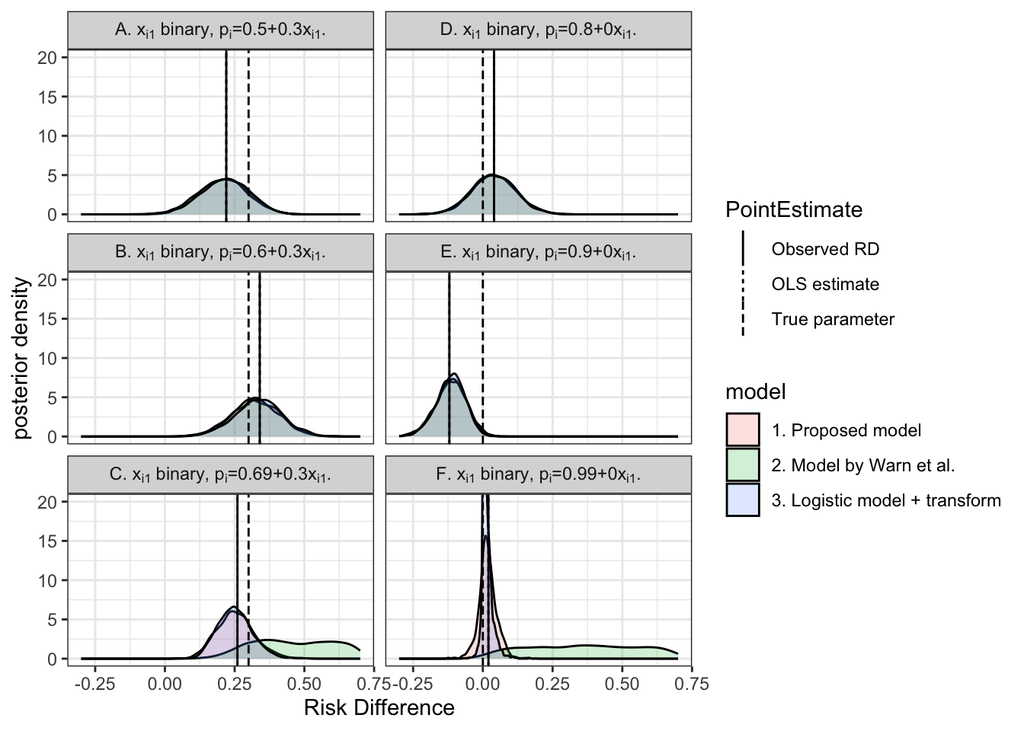

```r
rm(cure, trial.dat, true.beta, true.p)

###Plots

beta.plot$Scenario <- factor(beta.plot$Scenario,
                   levels=c("1x_bin_p=0.5+0.3x",
                            "1x_bin_p=0.6+0.3x",
                            "1x_bin_p=0.69+0.3x",
                            "1x_bin_p=0.8+0x",
                            "1x_bin_p=0.9+0x",
                            "1x_bin_p=0.99+0x"),
                   labels=c(expression(paste("A. ", x[i*1], " binary, ", p[i],"=0.5+0.3",x[i*1],".")),
                            expression(paste("B. ", x[i*1], " binary, ", p[i],"=0.6+0.3",x[i*1],".")),
                            expression(paste("C. ", x[i*1], " binary, ", p[i],"=0.69+0.3",x[i*1],".")),
                            expression(paste("D. ", x[i*1], " binary, ", p[i],"=0.8+0",x[i*1],".")),
                            expression(paste("E. ", x[i*1], " binary, ", p[i],"=0.9+0",x[i*1],".")),
                            expression(paste("F. ", x[i*1], " binary, ", p[i],"=0.99+0",x[i*1],"."))
                            ))

xicpt.plot$Scenario <- factor(xicpt.plot$Scenario,
                   levels=c("1x_bin_p=0.5+0.3x",
                            "1x_bin_p=0.6+0.3x",
                            "1x_bin_p=0.69+0.3x",
                            "1x_bin_p=0.8+0x",
                            "1x_bin_p=0.9+0x",
                            "1x_bin_p=0.99+0x"),
                   labels=c(expression(paste("A. ", x[i*1], " binary, ", p[i],"=0.5+0.3",x[i*1],".")),
                            expression(paste("B. ", x[i*1], " binary, ", p[i],"=0.6+0.3",x[i*1],".")),
                            expression(paste("C. ", x[i*1], " binary, ", p[i],"=0.69+0.3",x[i*1],".")),
                            expression(paste("D. ", x[i*1], " binary, ", p[i],"=0.8+0",x[i*1],".")),
                            expression(paste("E. ", x[i*1], " binary, ", p[i],"=0.9+0",x[i*1],".")),
                            expression(paste("F. ", x[i*1], " binary, ", p[i],"=0.99+0",x[i*1],"."))
                            ))

##plot maken
    print(
    plot1 <- ggplot(beta.plot, aes(beta, fill = model)) +
    geom_density(alpha = 0.2) +
    geom_vline(data=xicpt.plot, aes(xintercept = xicpts, linetype=PointEstimate)) +
    ylab("posterior density")+
    xlab(expression("Risk Difference"))+
    xlim(beta_xlim)+
    ylim(beta_ylim)+
    theme_bw()+
    coord_cartesian(ylim=c(0,20))+
    facet_wrap(~Scenario, ncol = 2, dir = "v", labeller = label_parsed))
```

```r
ggsave(plot = plot1, filename="1x_bin.pdf", height=6, width = 7.5)
```